# PSY8712 Week 8 Project

Merhar

2024-03-17

## Reproducible Image and Online Resources

An image of this project as of *17 March 2024* can be accessed by [clicking this link](https://mybinder.org/v2/gh/merha013/psy8712-week8/HEAD?urlpath=rstudio).

An interactive web app is available by [clicking this link instead](https://merha013.shinyapps.io/week8/).

## Script Settings and Resources

```r
setwd(dirname(rstudioapi::getActiveDocumentContext()$path))
library(tidyverse)
```

## Data Import and Cleaning

The following code uses a single pipeline to create week8_tbl from the data (week3.csv). It converts the timeEnd data into its correct type, relabels the variables for gender (to match code used in radio buttons for the shiny app), and reverses the code for q5. I also created two additional columns called ‘average1’ and ‘average2’ that provide the means of q1-q6 and q8-q10 respectively since it is needed in the Visualization section.

```r
week8_tbl <- read_csv("../data/week3.csv") %>%
  mutate(timeEnd = ymd_hms(timeEnd),
         gender = recode_factor(gender,
                                M = "Male",
                                F = "Female"),
         q5 = max(q5)-q5+1,
         average1 = (q1+q2+q3+q4+q5+q6)/6,
         average2 = (q8+q9+q10)/3)
```

## Visualization

The table below shows the data contained in questions 1 through 6. It is paginated so the data will be less overwhelming and shows only ten rows at a time. Additionally, the scatterplot was created using the data from week8_tbl and placing the mean scores of questions 1-6 on the x-axis and the mean scores of questions 8-10 on the y-axis. A purple OLS regression line with a shaded error band is included in the depiction, and the input code to create this scatterplot has been hidden from the final output.

| q1 | q2 | q3 | q4 | q5 | q6 |
| --- | --- | --- | --- | --- | --- |
| 5 | 4 | 4 | 1 | 2 | 1 |
| 2 | 4 | 3 | 1 | 3 | 1 |
| 5 | 5 | 2 | 1 | 5 | 1 |
| 4 | 3 | 4 | 2 | 4 | 1 |
| 3 | 1 | 3 | 5 | 2 | 1 |
| 4 | 3 | 2 | 3 | 3 | 1 |
| 2 | 4 | 1 | 3 | 1 | 1 |
| 4 | 2 | 5 | 1 | 1 | 1 |
| 2 | 5 | 3 | 4 | 2 | 1 |
| 3 | 4 | 2 | 4 | 5 | 1 |

[output cut: 39 more lines]

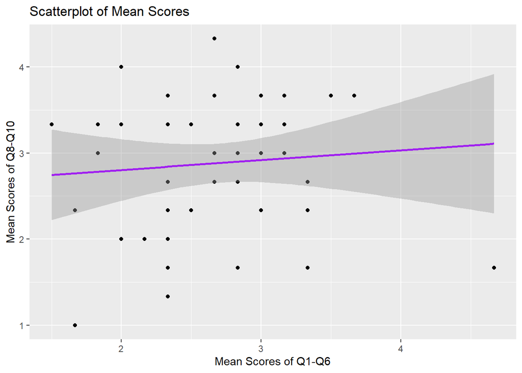

## Analysis

```
##
##  Pearson's product-moment correlation
##
## data:  week8_tbl$average1 and week8_tbl$average2
## t = 0.58309, df = 47, p-value = 0.5626
## alternative hypothesis: true correlation is not equal to 0
## 95 percent confidence interval:
##  -0.2012466  0.3574248
## sample estimates:
##        cor
## 0.08474575
```

I observed a correlation of .08 and a p-value of 0.5626235. This p-value means, using an $\alpha$=0.05, there is at least a 56.26235% probability of observing the collected data if there were truly no relationship between the mean of questions 1-6 and the mean of questions 8-10. Since 0.5626235 > $\alpha$, we fail to reject the null hypothesis that the true correlation is equal to 0. There is not enough evidence to conclude that there is a statistically significant relationship between the variables being tested at the 0.05 significance level.

## Data Export

A minimal/skinny version of the dataset appropriate for shiny has been created via a single series of pipes and exported.

```r
week8_tbl %>%
  select(timeEnd, gender, average1, average2) %>%
  saveRDS("../shiny/week8/skinny.rds")
```